# Case Study 1 : Data Science in Twitter Data

# Data Exploration: Exploring the Tweets and Tweet Entities

**(1) Word Count:**

- Load the tweets you collected in the local file (txt or json)
- compute the frequencies of the words being used in these tweets.
- Plot a table of the top 30 most-frequent words with their counts

```python
import prettytable
# Your code starts here
#   Please add comments or text cells in between to explain the general idea of each block of the code.
#   Please feel free to add more cells below this cell if necessary
with open('TeslaModel3.json',encoding='utf-8') as f:
    statuses = json.load(f)

status_texts = [ status['text']
                 for status in statuses ]

# Compute a collection of all words from all tweets
words = [ w
          for t in status_texts
              for w in t.split() ]

import nltk
from nltk.corpus import stopwords

nltk.download("stopwords")
meaningless_words = list(stopwords.words('english'))
meaningless_words+=['RT','https']

target_words=[]
for w in words:
    if w not in meaningless_words:
            target_words.append(w)

from collections import Counter

word_count = Counter(target_words)
print(word_count.most_common()[:30]) # top 30

#

from prettytable import PrettyTable

pt = PrettyTable(field_names=['Word', 'Count'])
[ pt.add_row(kv) for kv in word_count.most_common()[:30] ]
pt.align['Word'], pt.align['Count'] = 'l', 'r' # Set column alignment
print (pt)
```

```
[('I', 995), ('@Tesla', 862), ('#Model3', 770), ('@elonmusk', 440), ('#Tesla', 349), ('got', 297), ('Tesla', 263), ('asking', 256), ('received', 250), ('saying', 242), ('pick', 240), ('deposit', 238), ('text', 237), ('placed', 236), ('@kevinwood89:', 234), ('website.', 234), ('email', 234), ('design…
+---------------+-------+
| Word          | Count |
+---------------+-------+
| I             |   995 |
| @Tesla        |   862 |
| #Model3       |   770 |
| @elonmusk     |   440 |
| #Tesla        |   349 |
| got           |   297 |
| Tesla         |   263 |
| asking        |   256 |
| received      |   250 |
| saying        |   242 |
| pick          |   240 |
| deposit       |   238 |
| text          |   237 |
| placed        |   236 |
| @kevinwood89: |   234 |
| website.      |   234 |
| email         |   234 |
| design.       |   234 |
| AW…           |   234 |
| @InsideEVs:   |   227 |
| #model3       |   227 |
| 3             |   224 |
| car           |   211 |
| BMW           |   158 |
| back          |   158 |
| see           |   145 |
| The           |   136 |
| t…            |   134 |
| Model         |   133 |
| would         |   125 |
+---------------+-------+
```

**(2) Find the most popular tweets in your collection of tweets**

Please plot a table of the top 10 most-retweeted tweets in your collection, i.e., the tweets with the largest number of retweet counts.

```python
# Your code starts here
#   Please add comments or text cells in between to explain the general idea of each block of the code.
#   Please feel free to add more cells below this cell if necessary


retweets = [
            # Store out a tuple of these three values ...
            (status['retweet_count'],
             status['retweeted_status']['user']['screen_name'],
             status['text'])

            # ... for each status ...
            for status in statuses

            # ... so long as the status meets this condition.
                if status. __contains__('retweeted_status')
           ]

# Slice off the first 5 from the sorted results and display each item in the tuple

pt = PrettyTable(field_names=['Count', 'Screen Name', 'Text'])
[ pt.add_row(row) for row in sorted(retweets, reverse=True)[:10] ]
pt.max_width['Text'] = 50
pt.align= 'l'
print (pt)
```

```
+-------+----------------+----------------------------------------------------+
| Count | Screen Name    | Text                                               |
+-------+----------------+----------------------------------------------------+
| 31651 | _Tea_for_One_  | RT @_Tea_for_One_: 「動物園                        |
|       |                | 訓練」で画像検索したら見るのやめられなくなって昼休み潰れそうになってる |
|       |                | https://t.co/aiEWH8YcV2                            |
| 29071 | SplatoonJP     | RT @SplatoonJP: 新たなスペシャルウェポン「ナイスダマ」の詳細が判明した。 |
|       |                | 力を溜めてインクの塊を作り、投げつけて大爆発を起こせるぞ。 |
|       |                | 「ナイス」のシグナルを送ったり、仲間に送ってもらうと、素早く力が溜まるらしい。 |
|       |                | シグナルを送ってくれた仲間は、お礼に少しだけスペ…  |
| 27642 | poisoncookie00 | RT @poisoncookie00: 女の子のお泊まり・旅行で忘れがちなもの一覧（完全版）です。 |
|       |                | 確認等にお使いください。                           |
|       |                | ご協力頂いたフォロワーさん本当にありがとうございました😭 |
|       |                | https://t.co/MwaRWHARqq                            |
| 16791 | sprit4ever     | RT @sprit4ever: 이건 뭐야아 https://t.co/ya0lWBmyh9 |
| 16214 | nu_4t          | RT @nu_4t: クッパ姫を公式化させようみたいな署名があるらしいけど、署名だけで任天堂が動くな |
|       |                | らば今頃カービィのエアライドはあと2作くらいは出てる |
| 14813 | kirino_0214    | RT @kirino_0214: 妹「ドイツ語やばいよ！！！w」     |
|       |                | 兄「なにがww」                                     |
|       |                | 妹「『黒豚』ってドイツ語で『シュヴァルツシュヴァイン』とか無駄にカッコいいのに、『深紅の死神』とかい |
|       |                | かにも厨二的にカッコイイ単語が『プルプルンゼンゼンマン』とか無駄に可愛らしくて、ドイツ語まじわ… |
| 14523 | 3h4m1          | RT @3h4m1: 美容部員の方とお話する機会があり「洗顔は何を？保湿は？」と矢継ぎ早に聞かれ碌に |
|       |                | 化粧もしてない顔でつい真正直に                     |
|       |                |                                                    |
|       |                | 「せ、洗顔は家にある牛乳石鹸で、保湿はニベア一択」 |
|       |                |                                                    |
|       |                | と答えてしまい嘲笑されるかと思いきや               |
|       |                |                                                    |
|       |                | 「いい！伸び代しかないお答えですよぉ〜！」         |
|       |                |                                                    |
|       |                | 美容…                                              |
| 12102 | hiranokohta    | RT @hiranokohta: 「師匠、俺にはわからないんだ。クッパ姫とエロッている最中に王冠が取 |
|       |                | れて元のクッパに戻ってしまったら、いれていたちんこはどうなる」 |
|       |                | 「それは我々が30年前にらんま1/2で通った道じゃ・・永遠の謎なのじゃ・・」 |
|       |                | 「師匠・・・」                                     |
| 10898 | hiroshi_       | RT @hiroshi_: デザインのことは良く分かりませんが、もしもアップルが日本の会社だったらた |
|       |                | ぶんiPhoneはこうなってたと思います。 https://t.co/5qfcxFNlBc |
| 6361  | r_yuriii       | RT @r_yuriii: さっきあったことをありのままに話すんですが、移動中にスマホで漫画読んでた |
|       |                | ら「漫画村復活したんですか？」って高校生が絡んできて、「kindleですよ」って言ったら |
|       |                |                                                    |
|       |                | 高校生「キンドルってサイト、帰って探してみます！」 |
|       |                |                                                    |
|       |                | と去っていった。若さってすごいな…                  |
+-------+----------------+----------------------------------------------------+
```

**(3) Find the most popular Tweet Entities in your collection of tweets**

Please plot the top 10 most-frequent hashtags and top 10 most-mentioned users in your collection of tweets.

```python
# Your code starts here
#   Please add comments or text cells in between to explain the general idea of each block of the code.
#   Please feel free to add more cells below this cell if necessary

screen_names = [ user_mention['screen_name']
                 for status in statuses
                     for user_mention in status['entities']['user_mentions'] ]

hashtags = [ hashtag['text']
             for status in statuses
                 for hashtag in status['entities']['hashtags'] ]

for label, data in (('Screen Name', screen_names),
                    ('Hashtag', hashtags)):
    pt = PrettyTable(field_names=[label, 'Count'])
    c = Counter(data)
    [ pt.add_row(kv) for kv in c.most_common()[:10] ]
    pt.align[label], pt.align['Count'] = 'l', 'r' # Set column alignment
    print (pt)
```

```
+----------------+-------+
| Screen Name    | Count |
+----------------+-------+
| Tesla          |   908 |
| elonmusk       |   455 |
| InsideEVs      |   241 |
| kevinwood89    |   234 |
| Model3Owners   |   133 |
| BryanForst     |   120 |
| GerberKawasaki |    72 |
| Model3         |    38 |
| AnthonyHinkle1 |    31 |
| nrlacomba      |    30 |
+----------------+-------+
+-------------+-------+
| Hashtag     | Count |
+-------------+-------+
| Model3      |   835 |
| Tesla       |   361 |
| model3      |   260 |
| tesla       |   103 |
| teslamodel3 |    22 |
| BMW         |    22 |
| TeslaModel3 |    19 |
| TeamElon    |    18 |
| teslamotors |    15 |
| teslamodelx |    15 |
+-------------+-------+
```

```python
# Your code starts here
#   Please add comments or text cells in between to explain the general idea of each block of the code.
#   Please feel free to add more cells below this cell if necessary
bins=[10, 20, 30]
counts = [count for count, _, _ in retweets]
print(counts)
```

```
[32, 10, 1, 7, 10, 1, 132, 1, 5, 1, 5, 132, 5, 32, 5, 3, 3, 4, 5, 3, 1, 3, 132, 8, 267, 3, 9, 7, 5, 32, 5, 5, 5, 5, 1, 10, 4, 10, 132, 1, 8, 15, 9, 32, 15, 10, 15, 1, 7, 132, 132, 7, 1, 15, 32, 31, 10, 15, 4, 2, 1, 1, 31, 32, 2, 3, 10, 31, 4, 9, 23, 216, 17, 15, 15, 32, 9, 1, 1, 1, 2, 3, 2, 2, 104, …
```

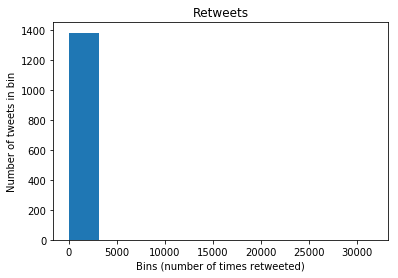

```python
import matplotlib.pyplot as plt
plt.hist(counts,10)
plt.title("Retweets")
plt.xlabel('Bins (number of times retweeted)')
plt.ylabel('Number of tweets in bin')
plt.show()
```

**(4) Getting "All" friends and "All" followers of a popular user in the tweets**

```python
from prettytable import PrettyTable
import time
name = 'kevinwood89'
size = 9
api = oauth_login()
followers_list = api.followers.ids(screen_name=name)
followers = followers_list['ids']
count = 0
while followers_list['next_cursor']:
    #every time get 5000 json objects
    followers_list = api.followers.ids(screen_name=name, cursor = followers_list['next_cursor'])
    followers += followers_list['ids']
    time.sleep(10)
    #time limit
    count +=1

friends = api.friends.ids(screen_name=name)
#this following is less than 5000, so we don't use the cursor
follow = api.users.lookup(user_id=followers[:size])
friend = api.users.lookup(user_id=friends['ids'][:size])


#plot 20 out of the followers' ID and screen names
count = 0
while len(follow)<size:
    follow += api.users.lookup(user_id=followers[size+count])
    count +=1


pt_fo = PrettyTable(field_names=['User Id','Screen Name'])
for i in range(size):
    [pt_fo.add_row([follow[i]['id_str'],follow[i]['screen_name']])]
    pt.max_width['Text'] = 50
    pt.align= 'l'
print(pt_fo)

while len(friend)<size:
    count = 0
    friend += api.users.lookup(user_id=friends['ids'][size+count])
    count +=1

pt_fr = PrettyTable(field_names=['User Id','Screen Nmae'])
for i in range(size):
    [pt_fr.add_row([friend[i]['id_str'],friend[i]['screen_name']])]
    pt_fr.max_width['Text'] = 50
    pt_fr.align= 'l'
print(pt_fr)
```

```
+---------------------+-----------------+
|       User Id       |   Screen Name   |
+---------------------+-----------------+
|      4360442295     |  EuroSteelSport |
| 1034822501723987969 |  charli52059706 |
|       34988827      | justindaffronte |
|      4888195616     |     iryusei0    |
|        714553       |    shadowphax   |
|  956548664150827008 | KushalJ20190623 |
|       66324800      |     Ophillee    |
|      2765370202     |      eyeora     |
|      2804516556     |  EZWorldAcademy |
+---------------------+-----------------+
+--------------------+-----------------+
| User Id            | Screen Nmae     |
+--------------------+-----------------+
| 3898598357         | _youhadonejob1  |
| 402295384          | CIO_CAN         |
| 625992111          | BCJRCanucksBric |
| 28612106           | bchydro         |
| 4549776312         | Hplhockey       |
| 719674147442421760 | ReillyJonesy    |
| 4193791632         | bcmayhem        |
| 25073877           | realDonaldTrump |
| 25073877           | realDonaldTrump |
+--------------------+-----------------+
```

```python
print(len(friends['ids']))
```

```
74
```

# The Solution: implement a data science solution to the problem you are trying to solve.

1. Briefly describe the idea of your solution to the problem in the following cell:

We use sentiment analysis to see whether the overall feedback is positive or not. Therefore, we further explore the positive and negative tweets.

1. Write codes to implement the solution in python:

```python
# Your code starts here
#   Please add comments or text cells in between to explain the general idea of each block of the code.
#   Please feel free to add more cells below this cell if necessary
import tweepy
from textblob import TextBlob
import twitter
import pandas as pd

CONSUMER_KEY = 'jgJJDAqzlfgzz8F2srFqDRudx'
CONSUMER_SECRET = 'AjV8yfhNR1KPMBlAhphn43eJTRrkhW5M4MqfSGVV55v6fVpN1z'
OAUTH_TOKEN = '706743847053873152-1D8YWiREEx72PKChEjkivhmK00MPwDY'
OAUTH_TOKEN_SECRET = 'IhsCqMntXFYbMywo1g8RWaJuqMzfi8UuZUczsSFY5z3qa'
#tweepy api
auth = tweepy.OAuthHandler(CONSUMER_KEY, CONSUMER_SECRET)
auth.set_access_token(OAUTH_TOKEN, OAUTH_TOKEN_SECRET)
api = tweepy.API(auth)
```

```python
# Function we used.
import nltk
from nltk.corpus import stopwords
from nltk.tokenize import word_tokenize
from nltk.tokenize import RegexpTokenizer
import re
from collections import Counter
from IPython.display import display
from operator import itemgetter
from wordcloud import WordCloud,STOPWORDS

def createSentimentalDF(pos_neg, subj_obj, tweets, tweets_cleaned, create_time):
    pos_neg_class = []
    for v in pos_neg:
        if v > 0.1:
            pos_neg_class.append('Positive')
        elif v < -0.1:
            pos_neg_class.append('Negative')
        else:
            pos_neg_class.append('Neutral')

    subj_obj_class = []
    for v in subj_obj:
        if v > 0.5:
            subj_obj_class.append('Subjective')
        elif v <= 0.5:
            subj_obj_class.append('Objective')


    sentimental_df = pd.DataFrame(data = {
        'Create_Time': create_time,
        'Full_Text': tweets,
        'Full_Text Cleaned': tweets_cleaned,
        'Polarity':pos_neg,
        'Polarity_Class': pos_neg_class,
        'Subjectivity':subj_obj,
        'Subjectivity_Class': subj_obj_class,
    })

    return sentimental_df
def splitIntoPosNeg(sentimental_df):
    # split sentimental_df
    # pos_df, pos_text, neg_df, neg_text
    pos_df = sentimental_df[
        sentimental_df.Polarity_Class == 'Positive'
    ]
    neg_df = sentimental_df[
        sentimental_df.Polarity_Class == 'Negative'
    ]

    pos_text = ''
    neg_text = ''
    for txt in neg_df.Full_Text:
        neg_text += txt
    for txt in pos_df.Full_Text:
        pos_text += txt

    return pos_df, pos_text, neg_df, neg_text


from nltk.corpus import stopwords
from nltk.tokenize import word_tokenize
def cleanTextData(text):
    #Input: text
    #Output: cleaned word list

    # lower words
    text = text.lower()

    # remove urls
    text = re.sub(r'http\S+', '', text)

    # remove punctuation and tokenize
    tokenizer = RegexpTokenizer(r'\w+')
    wordTokenized = tokenizer.tokenize(text)

    # remove stopwords
    stop_words = set(stopwords.words('english'))
    filtered_sentence = []
    for w in wordTokenized:
        if w not in stop_words and w != 'rt' and w != 'RT' and not w.startswith('@')\
         and not w.startswith('#') and w != '3' and w!= 'tesla' and w!='elonmusk' and w!='model3'\
         and w!='teslamodel3' and w!='amp' and w!='model' :
            filtered_sentence.append(w)
    return filtered_sentence


def wordCountAndSort(wordList):
    #Input wordlist
    #Output dataframe with sorted word count
    wordCnt = dict(Counter(wordList))
    df = pd.DataFrame(sorted(wordCnt.items(), key=itemgetter(1), reverse = True))
    df.columns = ['word','count']

    return df

def wordcloud_draw(data, color = 'white'):
    # input: cleeaned text (string)
    words = ' '.join(data)
    cleaned_word = " ".join([word for word in words.split()
                            if 'http' not in word
                                and not word.startswith('@')
                                and not word.startswith('#')
                                and word != 'RT' and word != 'rt'
                            ])
    wordcloud = WordCloud(stopwords=STOPWORDS,
                      background_color=color,
                      width=2500,
                      height=2000
                     ).generate(cleaned_word)
    plt.figure(1,figsize=(13, 13))
    plt.imshow(wordcloud)
    plt.axis('off')
    plt.show()
```

```python
text = 'You Can Now Buy A Great Discounted #TeslaModel3  Demo Car https://goo.gl/NzokjN '
cleanTextData(text)
```

```
['buy', 'great', 'discounted', 'demo', 'car']
```

### Dataset 1 extracted from #TeslaModel3

```python
#df1
#extract 1850 tweets from #TeslaModel3
#Do sentimental analysis
create_time = []
tweets = []
tweets_cleaned = []
pos_neg = []
subj_obj = []
for tweet in tweepy.Cursor(api.search, q='#TeslaModel3', tweet_mode='extended').items(1850):
    # create time
    create_time.append(tweet.created_at)

    # get full text
    text = tweet.full_text
    tweets.append(text)

    # get cleaned full text
    text_cleaned = cleanTextData(text)
    tweets_cleaned.append(text_cleaned)

    # sentimental analysis
    analysis = TextBlob(tweet.full_text).sentiment
    # positive/negative   subjective/objective
    pos_neg.append(analysis.polarity)
    subj_obj.append(analysis.subjectivity)
```

```python
#df1-create
TeslaModel3_df = createSentimentalDF(pos_neg, subj_obj, tweets,tweets_cleaned, create_time)
#split into positive and negative text
TeslaModel3_pos_df, TeslaModel3_pos_text, TeslaModel3_neg_df, TeslaModel3_neg_text = splitIntoPosNeg(TeslaModel3_df)

TeslaModel3_cleaned_wordlist_pos = cleanTextData(TeslaModel3_pos_text)
TeslaModel3_cleaned_wordlist_neg = cleanTextData(TeslaModel3_neg_text)
#positive/negative word count
TeslaModel3_pos_wordcnt = wordCountAndSort(TeslaModel3_cleaned_wordlist_pos)
TeslaModel3_neg_wordcnt = wordCountAndSort(TeslaModel3_cleaned_wordlist_neg)
```

```python
display(TeslaModel3_df.head())
print(TeslaModel3_df.shape)
```

|  | Create_Time | Full_Text | Full_Text Cleaned | Polarity | Polarity_Class | Subjectivity | Subjectivity_Class |
| --- | --- | --- | --- | --- | --- | --- | --- |
| 0 | 2018-09-27 15:18:38 | @milanstudio @BMW Meanwhile #volvo and it's #p... | [milanstudio, bmw, meanwhile, volvo, polestar,... | 0.416667 | Positive | 0.750000 | Subjective |
| 1 | 2018-09-27 15:15:37 | RT @Dante_Tesla: Panasonic liegt bei der Erwei... | [dante_tesla, panasonic, liegt, bei, der, erwe... | 0.000000 | Neutral | 0.000000 | Objective |
| 2 | 2018-09-27 15:08:34 | #model3 #teslamodel3 closing in on 10K/week.\n... | [closing, 10k, week, teamelon, teamelon] | 0.000000 | Neutral | 0.000000 | Objective |
| 3 | 2018-09-27 15:07:25 | Watch #TeslaModel3 Performance Lay Down New 1... | [watch, performance, lay, new, 1, 4, mile, rec... | -0.009596 | Neutral | 0.371717 | Objective |
| 4 | 2018-09-27 14:49:05 | @Model3Owners #teslamodel3\n Not the best gram... | [model3owners, best, grammar, happy, txt, able... | 0.653125 | Positive | 0.564583 | Subjective |

```
(1844, 7)
```

### Dataset 2 extracted from Model3

```python
#df2
#extract 1800 tweets from Model3
#Do sentimental analysis
create_time2 = []
tweets2 = []
tweets_cleaned2 = []
pos_neg2 = []
subj_obj2 = []
for tweet in tweepy.Cursor(api.search, q='Model3', tweet_mode='extended').items(1800):
    # create time
    create_time2.append(tweet.created_at)

    # get full text
    text = tweet.full_text
    tweets2.append(text)

    # get cleaned full text
    text_cleaned = cleanTextData(text)
    tweets_cleaned2.append(text_cleaned)

    # sentimental analysis
    analysis = TextBlob(tweet.full_text).sentiment
    # positive/negative   subjective/objective
    pos_neg2.append(analysis.polarity)
    subj_obj2.append(analysis.subjectivity)
```

```python
#df2-create
TeslaModel3_df2 = createSentimentalDF(pos_neg2, subj_obj2, tweets2,tweets_cleaned2, create_time2)

TeslaModel3_pos_df2, TeslaModel3_pos_text2, TeslaModel3_neg_df2, TeslaModel3_neg_text2 = splitIntoPosNeg(TeslaModel3_df2)

TeslaModel3_cleaned_wordlist_pos2 = cleanTextData(TeslaModel3_pos_text2)
TeslaModel3_cleaned_wordlist_neg2 = cleanTextData(TeslaModel3_neg_text2)

TeslaModel3_pos_wordcnt2 = wordCountAndSort(TeslaModel3_cleaned_wordlist_pos2)
TeslaModel3_neg_wordcnt2 = wordCountAndSort(TeslaModel3_cleaned_wordlist_neg2)
```

```python
display(TeslaModel3_df2.head())
print(TeslaModel3_df2.shape)
```

|  | Create_Time | Full_Text | Full_Text Cleaned | Polarity | Polarity_Class | Subjectivity | Subjectivity_Class |
| --- | --- | --- | --- | --- | --- | --- | --- |
| 0 | 2018-09-27 18:16:05 | RT @28delayslater: I put my aero caps back on ... | [28delayslater, put, aero, caps, back, cause, ... | 0.000000 | Neutral | 0.000000 | Objective |
| 1 | 2018-09-27 18:14:26 | @elonmusk I ordered your #Model3 last month an... | [ordered, last, month, night, 11pm, received, ... | -0.056250 | Neutral | 0.495139 | Objective |
| 2 | 2018-09-27 18:13:07 | RT @InsideEVs: So, if the question is, which @... | [insideevs, question, buy, check, video, compa... | 0.000000 | Neutral | 0.000000 | Objective |
| 3 | 2018-09-27 18:12:54 | RT @InsideEVs: The @Tesla #Model3 Performance ... | [insideevs, performance, zips, track, set, new... | -0.339731 | Negative | 0.581145 | Subjective |
| 4 | 2018-09-27 18:12:49 | RT @InsideEVs: Save up to almost $3,000 and ta... | [insideevs, save, almost, 000, take, immediate... | 0.000000 | Neutral | 0.000000 | Objective |

```
(1800, 7)
```

### Dataset 3 extracted from elonmusk

```python
#df3
#extract 1800 tweets from elonmusk
#Do sentimental analysis
create_time3 = []
tweets3 = []
tweets_cleaned3 = []
pos_neg3 = []
subj_obj3 = []

for tweet in tweepy.Cursor(api.user_timeline, id="elonmusk", tweet_mode='extended').items(2000):
    # create time
    create_time3.append(tweet.created_at)

    # get full text
    text = tweet.full_text
    tweets3.append(text)

    # get cleaned full text
    text_cleaned = cleanTextData(text)
    tweets_cleaned3.append(text_cleaned)

    # sentimental analysis
    analysis = TextBlob(tweet.full_text).sentiment
    # positive/negative   subjective/objective
    pos_neg3.append(analysis.polarity)
    subj_obj3.append(analysis.subjectivity)
```

```python
#df2-create
TeslaModel3_df3 = createSentimentalDF(pos_neg3, subj_obj3, tweets3,tweets_cleaned3, create_time3)

TeslaModel3_pos_df3, TeslaModel3_pos_text3, TeslaModel3_neg_df3, TeslaModel3_neg_text3 = splitIntoPosNeg(TeslaModel3_df3)

TeslaModel3_cleaned_wordlist_pos3 = cleanTextData(TeslaModel3_pos_text3)
TeslaModel3_cleaned_wordlist_neg3 = cleanTextData(TeslaModel3_neg_text3)

TeslaModel3_pos_wordcnt3 = wordCountAndSort(TeslaModel3_cleaned_wordlist_pos3)
TeslaModel3_neg_wordcnt3 = wordCountAndSort(TeslaModel3_cleaned_wordlist_neg3)
```

```python
display(TeslaModel3_df3.head())
print(TeslaModel3_df3.shape)
```

|  | Create_Time | Full_Text | Full_Text Cleaned | Polarity | Polarity_Class | Subjectivity | Subjectivity_Class |
| --- | --- | --- | --- | --- | --- | --- | --- |
| 0 | 2018-09-27 03:26:28 | RT @geekwire: Japan’s ispace strikes deal with... | [geekwire, japan, ispace, strikes, deal, space... | 0.0000 | Neutral | 0.00 | Objective |
| 1 | 2018-09-26 18:25:49 | @scottwww @Tesla Pace of innovation is all tha... | [scottwww, pace, innovation, matters, long, run] | -0.0500 | Neutral | 0.40 | Objective |
| 2 | 2018-09-26 17:44:11 | @ctbarker32 @BDL3J @Tesla You’re welcome. Sorr... | [ctbarker32, bdl3j, welcome, sorry, delay] | 0.0875 | Neutral | 0.95 | Subjective |
| 3 | 2018-09-26 17:37:29 | @Agent_KO @Starflightgame @SpaceX @starcontrol... | [agent_ko, starflightgame, spacex, starcontrol... | 0.5875 | Positive | 0.75 | Subjective |
| 4 | 2018-09-25 20:45:23 | @neveryb Going over final tweaks tonight. Hope... | [neveryb, going, final, tweaks, tonight, hopef... | -0.0500 | Neutral | 0.70 | Subjective |

```
(2000, 7)
```

```python
#extract 5 most popular tweets from api.search, q='#TeslaModel3'
#Do sentimental analysis
create_time4 = []
tweets4 = []
tweets_cleaned4 = []
pos_neg4 = []
subj_obj4 = []

for tweet in tweepy.Cursor(api.search, q='#Model3', tweet_mode='extended', result_type='popular').items(10):
    # create tim
    create_time4.append(tweet.created_at)

    # get full text
    text = tweet.full_text
    tweets4.append(text)

    # get cleaned full text
    text_cleaned = cleanTextData(text)
    tweets_cleaned4.append(text_cleaned)

    # sentimental analysis
    analysis = TextBlob(tweet.full_text).sentiment
    # positive/negative   subjective/objective
    pos_neg4.append(analysis.polarity)
    subj_obj4.append(analysis.subjectivity)
```

```python
#df4-create
TeslaModel3_df4 = createSentimentalDF(pos_neg4, subj_obj4, tweets4,tweets_cleaned4, create_time4)

TeslaModel3_df4
```

|  | Create_Time | Full_Text | Full_Text Cleaned | Polarity | Polarity_Class | Subjectivity | Subjectivity_Class |
| --- | --- | --- | --- | --- | --- | --- | --- |
| 0 | 2018-09-26 22:31:47 | Guess where I just got back from. Doing the re... | [guess, got, back, real, research, needs, done... | 0.033333 | Neutral | 0.133333 | Objective |
| 1 | 2018-09-24 23:00:33 | Tesla production last qtr was a total of 41k #... | [production, last, qtr, total, 41k, delivered,... | -0.025000 | Neutral | 0.254167 | Objective |
| 2 | 2018-09-18 04:28:00 | The Audi Etron is a good #EV car for people wh... | [audi, etron, good, ev, people, like, audi, wa... | 0.525000 | Positive | 0.625000 | Subjective |
| 3 | 2018-09-22 15:53:04 | A first in business history as far as I can re... | [first, business, history, far, remember, elon... | 0.450000 | Positive | 0.777778 | Subjective |
| 4 | 2018-09-17 18:01:04 | Para los que se pregunten si el #Tesla #Model3... | [para, los, que, se, pregunten, si, el, tiene,... | 0.000000 | Neutral | 0.000000 | Objective |
| 5 | 2018-09-18 04:24:38 | Audi Etron thoughts. It’s ok. Pretty expensive... | [audi, etron, thoughts, ok, pretty, expensive,... | 0.175000 | Positive | 0.716667 | Subjective |
| 6 | 2018-09-20 14:06:02 | Tesla up $5 as #model3 ranked safest car on th... | [5, ranked, safest, road, saying, people, got,... | 1.000000 | Positive | 1.000000 | Subjective |
| 7 | 2018-09-21 10:00:32 | El #Tesla #Model3 consigue la máxima puntuació... | [el, consigue, la, máxima, puntuación, posible... | 0.000000 | Neutral | 0.000000 | Objective |
| 8 | 2018-09-23 14:40:01 | Tesla #Model3 = #1 Best Selling Car In The #US... | [1, best, selling, us, revenue, automotive, sa... | 1.000000 | Positive | 0.300000 | Objective |

# Results: summarize and visualize the results discovered from the analysis

Please use figures, tables, or videos to communicate the results with the audience.

```python
#neutral
print( TeslaModel3_df4['Full_Text'][1] )
print( TeslaModel3_df4['Full_Text Cleaned'][1] )
```

```
Tesla production last qtr was a total of 41k #model3 delivered according to Bloomberg. We have a vin assigned for this week at 111k. Thats 70k cars above the end of the qtr estimate. Minus 10k cars in transit means Tesla made a heck of a lot of cars this qtr. 60k...  $TSLA
['production', 'last', 'qtr', 'total', '41k', 'delivered', 'according', 'bloomberg', 'vin', 'assigned', 'week', '111k', 'thats', '70k', 'cars', 'end', 'qtr', 'estimate', 'minus', '10k', 'cars', 'transit', 'means', 'made', 'heck', 'lot', 'cars', 'qtr', '60k', 'tsla']
```

```python
#positive
print( TeslaModel3_df4['Full_Text'][2] )
print( TeslaModel3_df4['Full_Text Cleaned'][2] )
```

```
The Audi Etron is a good #EV car for people who like Audi’s and want to drop $80k. But for $60k a #model3 will dust it on every level. Range speed looks price performance.  Brain and of course cool. $tsla
['audi', 'etron', 'good', 'ev', 'car', 'people', 'like', 'audi', 'want', 'drop', '80k', '60k', 'dust', 'every', 'level', 'range', 'speed', 'looks', 'price', 'performance', 'brain', 'course', 'cool', 'tsla']
```

```python
print(TeslaModel3_df2[TeslaModel3_df2.Polarity_Class == 'Negative'].loc[1337,]['Full_Text'])
print(TeslaModel3_df2[TeslaModel3_df2.Polarity_Class == 'Negative'].loc[1337,]['Full_Text Cleaned'])
```

```
Still confused if this is a @Tesla or @SlackerRadio issue in my #Model3 but I have a premium Slacker account but I don't get a music back button on the center screen so I can't repeat a song which seems quite odd. Please advise #Tesla @elonmusk
['still', 'confused', 'slackerradio', 'issue', 'premium', 'slacker', 'account', 'get', 'music', 'back', 'button', 'center', 'screen', 'repeat', 'song', 'seems', 'quite', 'odd', 'please', 'advise']
```

#### sentimental distribution

```python
import warnings
warnings.filterwarnings("ignore")

boxplot_df = TeslaModel3_df[['Polarity','Subjectivity_Class']]
boxplot_df['Source'] = ' #TeslaModel3'

boxplot_df2 = TeslaModel3_df2[['Polarity','Subjectivity_Class']]
boxplot_df2['Source'] = 'Model3'

boxplot_df3 = TeslaModel3_df3[['Polarity','Subjectivity_Class']]
boxplot_df3['Source'] = 'elonmusk'

boxplot_final_df = pd.concat([boxplot_df,boxplot_df2,boxplot_df3])
```

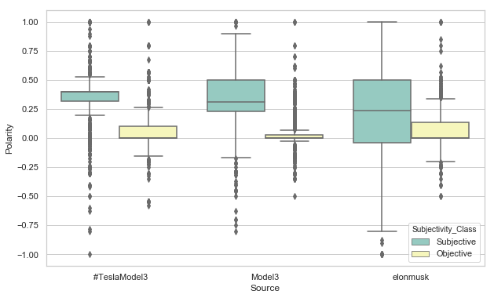

```python
plt.figure(figsize=(10,6))
sns.boxplot(x="Source", y="Polarity", hue="Subjectivity_Class",
                 data=boxplot_final_df, linewidth=1.5, palette="Set3")
```

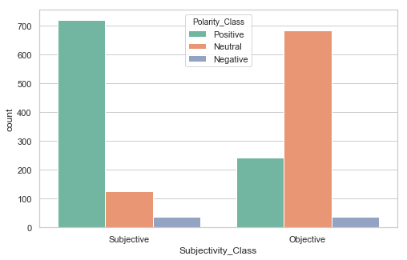

```python
# dataset 1 sentimental distribution
import seaborn as sns
plt.figure(figsize=(8,5))
sns.set(style="whitegrid")
sns.countplot(TeslaModel3_df['Subjectivity_Class'],\
              hue=TeslaModel3_df['Polarity_Class'],\
              palette="Set2", order = ['Subjective', 'Objective'])
```

```python
print( Counter(TeslaModel3_df.Polarity_Class) )
print( Counter(TeslaModel3_df.Subjectivity_Class) )
```

```
Counter({'Positive': 961, 'Neutral': 809, 'Negative': 74})
Counter({'Objective': 962, 'Subjective': 882})
```

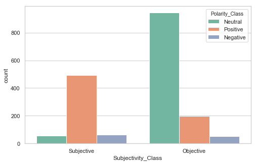

```python
# dataset 2 sentimental distribution
import seaborn as sns
import matplotlib.pyplot as plt
plt.figure(figsize=(8,5))
sns.set(style="whitegrid")
sns.countplot(TeslaModel3_df2['Subjectivity_Class'],\
              hue=TeslaModel3_df2['Polarity_Class'],\
              palette="Set2", order = ['Subjective', 'Objective'])
```

```python
print( Counter(TeslaModel3_df2.Polarity_Class) )
print( Counter(TeslaModel3_df2.Subjectivity_Class) )
```

```
Counter({'Neutral': 997, 'Positive': 688, 'Negative': 115})
Counter({'Objective': 1192, 'Subjective': 608})
```

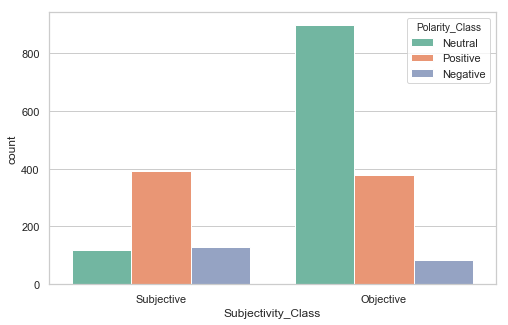

```python
# dataset 3 sentimental distribution
import seaborn as sns
import matplotlib.pyplot as plt
plt.figure(figsize=(8,5))
sns.set(style="whitegrid")
sns.countplot(TeslaModel3_df3['Subjectivity_Class'],\
              hue=TeslaModel3_df3['Polarity_Class'],\
              palette="Set2", order = ['Subjective', 'Objective'])
```

```python
print( Counter(TeslaModel3_df3.Polarity_Class) )
print( Counter(TeslaModel3_df3.Subjectivity_Class) )
```

```
Counter({'Neutral': 1015, 'Positive': 772, 'Negative': 213})
Counter({'Objective': 1358, 'Subjective': 642})
```

positive and negative separately

```python
TeslaModel3_pos_wordcnt3.iloc[0:50,]
```

|  | word | count |
| --- | --- | --- |
| 0 | good | 74 |
| 1 | spacex | 69 |
| 2 | love | 47 |
| 3 | great | 45 |
| 4 | people | 41 |
| 5 | better | 37 |
| 6 | thanks | 35 |
| 7 | first | 35 |
| 8 | new | 32 |
| 9 | make | 30 |
| 10 | would | 29 |
| 11 | like | 27 |
| 12 | really | 27 |
| 13 | much | 26 |
| 14 | true | 26 |
| 15 | team | 26 |
| 16 | work | 26 |
| 17 | right | 25 |
| 18 | many | 24 |
| 19 | best | 24 |
| 20 | way | 24 |
| 21 | could | 23 |
| 22 | actually | 23 |
| 23 | also | 22 |
| 24 | fun | 22 |
| 25 | sure | 22 |
| 26 | high | 22 |
| 27 | exactly | 22 |
| 28 | even | 22 |
| 29 | yeah | 21 |
| 30 | rocket | 21 |
| 31 | time | 21 |
| 32 | one | 21 |
| 33 | falcon | 21 |
| 34 | cars | 21 |
| 35 | super | 20 |
| 36 | soon | 20 |
| 37 | ok | 20 |
| 38 | cool | 20 |
| 39 | performance | 18 |
| 40 | production | 18 |
| 41 | think | 18 |
| 42 | 5 | 17 |
| 43 | see | 17 |
| 44 | need | 17 |
| 45 | factory | 17 |
| 46 | amazing | 17 |
| 47 | 1 | 17 |
| 48 | maybe | 17 |
| 49 | point | 16 |

```python
TeslaModel3_neg_wordcnt3.iloc[0:30,]
```

|  | word | count |
| --- | --- | --- |
| 0 | boring | 34 |
| 1 | company | 20 |
| 2 | heavy | 16 |
| 3 | one | 12 |
| 4 | sorry | 11 |
| 5 | falcon | 11 |
| 6 | people | 11 |
| 7 | get | 10 |
| 8 | false | 10 |
| 9 | make | 10 |
| 10 | know | 9 |
| 11 | even | 9 |
| 12 | would | 8 |
| 13 | 2 | 8 |
| 14 | time | 8 |
| 15 | hard | 8 |
| 16 | 1 | 8 |
| 17 | like | 8 |
| 18 | w | 7 |
| 19 | really | 7 |
| 20 | work | 7 |
| 21 | spacex | 7 |
| 22 | take | 7 |
| 23 | hat | 7 |
| 24 | base | 6 |
| 25 | production | 6 |
| 26 | air | 6 |
| 27 | also | 6 |
| 28 | want | 6 |
| 29 | yeah | 5 |

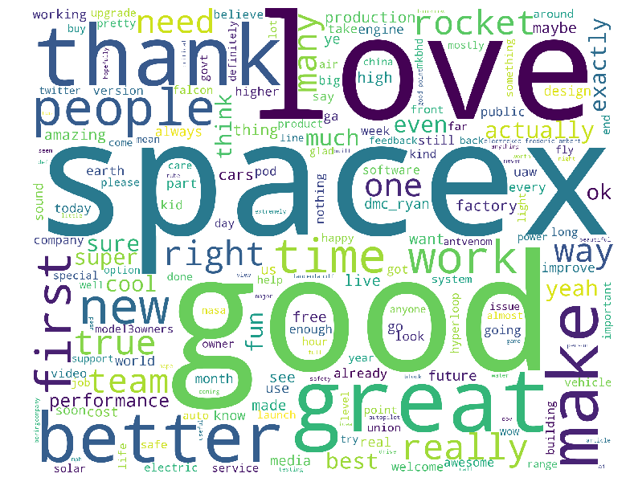

```python
import matplotlib.pyplot as plt

wordcloud_draw(TeslaModel3_cleaned_wordlist_pos3, color = 'white')
```

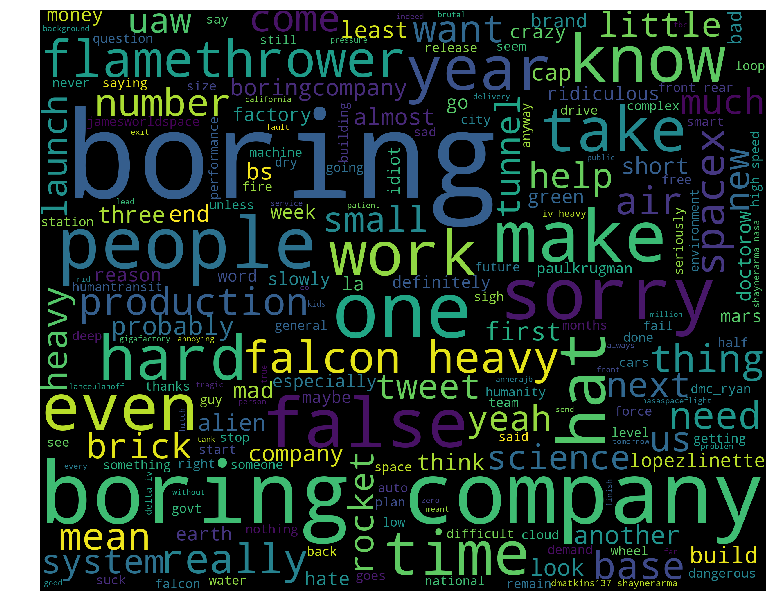

```python
import matplotlib.pyplot as plt
wordcloud_draw(TeslaModel3_cleaned_wordlist_neg3, color = 'black')
```

# Done

All set!

**What do you need to submit?**

- **Notebook File**: Save this Jupyter notebook, and find the notebook file in your folder (for example, "filename.ipynb"). This is the file you need to submit. Please make sure all the plotted tables and figures are in the notebook. If you used "jupyter notebook --pylab=inline" to open the notebook, all the figures and tables should have shown up in the notebook.
- **PPT Slides**: please prepare PPT slides (for 7 minutes' talk) to present about the case study . Each team present their case studies in class for 7 minutes.

Please compress all the files in a zipped file.

**How to submit:**

```
    Please submit through Canvas, in the Assignment "Case Study 1".
```

**Note: Each team only needs to submit one submission in Canvas**

# Peer-Review Grading Template:

**Total Points: (100 points)** Please don't worry about the absolute scores, we will rescale the final grading according to the performance of all teams in the class.

Please add an "**X**" mark in front of your rating:

For example:

*2: bad*

**X** *3: good*

*4: perfect*

```
---------------------------------
The Problem:
---------------------------------

1. (5 points) how well did the team describe the problem they are trying to solve using twitter data?
   0: not clear
   1: I can barely understand the problem
   2: okay, can be improved
   3: good, but can be improved
   4: very good
   5: crystal clear

2. (10 points) do you think the problem is important or has a potential impact?
    0: not important at all
    2: not sure if it is important
    4: seems important, but not clear
    6: interesting problem
    8: an important problem, which I want to know the answer myself
   10: very important, I would be happy invest money on a project like this.

----------------------------------
Data Collection:
----------------------------------

3. (10 points) Do you think the data collected are relevant and sufficient for solving the above problem?
   0: not clear
   2: I can barely understand what data they are trying to collect
   4: I can barely understand why the data is relevant to the problem
   6: the data are relevant to the problem, but better data can be collected
   8: the data collected are relevant and at a proper scale (> 300 tweets)
  10: the data are properly collected and they are sufficient

-----------------------------------
Data Exploration:
-----------------------------------
4. How well did the team solve the following task:
(1) Word Count (5 points):
   0: missing answer
   1: okay, but with major problems
   3: good, but with minor problems
   5: perfect

(2) Find the most popular tweets in your collection of tweets: (5 points)
   0: missing answer
   1: okay, but with major problems
   3: good, but with minor problems
   5: perfect

(3) Find popular twitter entities  (5 points)
   0: missing answer
   1: okay, but with major problems
   3: good, but with minor problems
   5: perfect

(4) Find user's followers and friends (5 points)
   0: missing answer
   1: okay, but with major problems
   3: good, but with minor problems
   5: perfect

-----------------------------------
The Solution
-----------------------------------
5.  how well did the team describe the solution they used to solve the problem?
   0: not clear
   2: I can barely understand
   4: okay, can be improved
   6: good, but can be improved
   8: very good
   10: crystal clear

6. how well is the solution in solving the problem?
   0: not relevant
   1: barely relevant to the problem
   2: okay solution, but there is an easier solution.
   3: good, but can be improved
   4: very good, but solution is simple/old
   5: innovative and technically sound

7. how well did the team implement the solution in python?
   0: the code is not relevant to the solution proposed
   2: the code is barely understandable, but not relevant
   4: okay, the code is clear but incorrect
   6: good, the code is correct, but with major errors
   8: very good, the code is correct, but with minor errors
  10: perfect

-----------------------------------
The Results
-----------------------------------
 8.  How well did the team present the results they found in the data?
   0: not clear
   2: I can barely understand
   4: okay, can be improved
   6: good, but can be improved
   8: very good
  10: crystal clear

 9.  How do you think the results they found in the data?
   0: not clear
   1: likely to be wrong
   2: okay, maybe wrong
   3: good, but can be improved
   4: make sense, but not interesting
   5: make sense and very interesting

-----------------------------------
The Presentation
-----------------------------------
10. How all the different parts (data, problem, solution, result) fit together as a coherent story?
   0: they are irrelevant
   1: I can barely understand how they are related to each other
   2: okay, the problem is good, but the solution doesn't match well, or the problem is not solvable.
   3: good, but the results don't make much sense in the context
   4: very good fit, but not exciting (the storyline can be improved/polished)
   5: a perfect story

11. Did the presenter make good use of the 10 minutes for presentation?
   0: the team didn't present
   1: bad, barely finished a small part of the talk
   2: okay, barely finished most parts of the talk.
   3: good, finished all parts of the talk, but some part is rushed
   4: very good, but the allocation of time on different parts can be improved.
   5: perfect timing and good use of time

12. How well do you think of the presentation (overall quality)?
   0: the team didn't present
   1: bad
   2: okay
   3: good
   4: very good
   5: perfect


-----------------------------------
Overall:
-----------------------------------
13. How many points out of the 100 do you give to this project in total?  Please don't worry about the absolute scores, we will rescale the final grading according to the performance of all teams in the class.
Total score:

14. What are the strengths of this project? Briefly, list up to 3 strengths.
   1:
   2:
   3:

15. What are the weaknesses of this project? Briefly, list up to 3 weaknesses.
   1:
   2:
   3:

16. Detailed comments and suggestions. What suggestions do you have for this project to improve its quality further.




---------------------------------
Your Vote:
---------------------------------
[Overall Quality] Between the two submissions that you are reviewing, which team would you vote for a better score?
    0: I vote the other team is better than this team
    1: I vote this team is better than the other team
```